# Data Science Capstone Project

[figure not shown]

Text Prediction Application in Shiny - [Next-texT](https://ermckinnon.shinyapps.io/NEXT-TEXT/)  
Ewen McKinnon, October 2016

## 1. Project Background

## Challenge

- Develop a text prediction application which predicts the next word in a sentence of text typed in by a user.
- The app must offer a choice of predictions.
- It should provide results in a reasonable time and operate within the typical memory constraints of mobile phones.

## Approach

- Use freely available corpus [HC Corpora](http://www.corpora.heliohost.org/aboutcorpus.html) which includes:  
  – 2.4 million lines of tweets  
  – 77 thousand lines of news  
  – 899 thousand lines of blogs
- Use 70% of corpus for training and 30% for testing
- Compare models on prediction accuracy, prediction time and memory usage
- Implement the best model as a [shiny](http://shiny.rstudio.com) application

## 2. Next-texT explained

- [Next-texT](https://ermckinnon.shinyapps.io/NEXT-TEXT/) predicts text based on stored n-gram tables (see box below). The n-gram tables are developed from frequency counts within the training corpus.

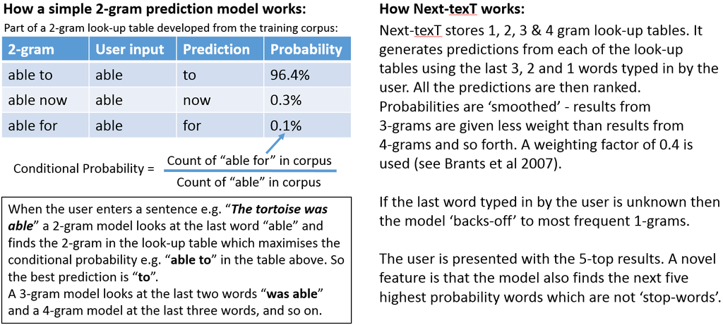

## 3. Next-texT Performance

- Models were tested on 200 runs of 100 predictions
- Graphs show performance vs two of the many other models tested A and B
- [Next-texT](https://ermckinnon.shinyapps.io/NEXT-TEXT/) has an average accuracy of 29.23%, takes 0.5secs per prediction, and uses 232 Mbytes of memory

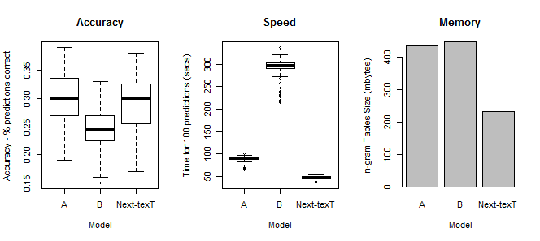

## 4. Using the Application

- The application can be found here: [Next-texT](https://ermckinnon.shinyapps.io/NEXT-TEXT/)
- The user interface is shown below:

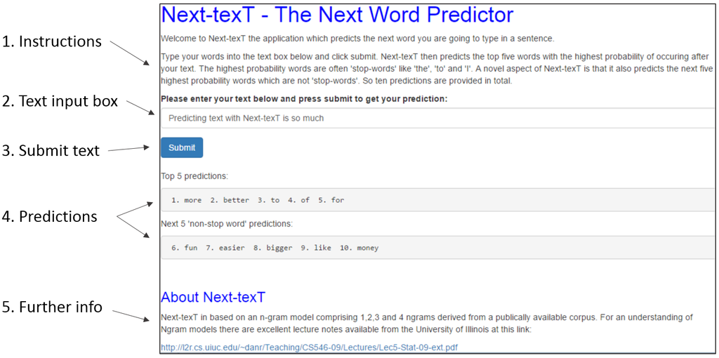

### 5. Lessons and References

### Project Lessons

- Developing the n-gram tables required 16GBytes of RAM to process half of the Corpus - it is memory intensive!
- Time & memory performance is enhanced by cutting low frequency n-grams from tables - Next-texT uses n-grams that occur >20 times in the training Corpus
- Next-Text could be enhanced with i. further tuning of back-off weights, ii. start-of-sentence identifiers

### References

- [Large Language Models in Machine Translation (2007)](http://www.aclweb.org/anthology/D07-1090.pdf)
- ngram tables are enhanced by [BYU Corpus](http://corpus.byu.edu/full-text/) probabilities
- All code is available at this [github](https://github.com/ermckinnon/CapstoneProject) link